# Final Exam R Shell

### introduction:

You can use this document as a place to read in your data and write your code for the final exam. You will need to write all your own code, but you can reference the labs that you already completed.

Reminder: to create a vector of values in R use code that looks like this:

myvector <- c(1,2,3,4)

[output not shown]

# Questions 1-10

You can use the R chunk below to perform any calculations you may want. There are no datasets to load for these questions.

```r
pbinom(19,100,.15)
```

```
[1] 0.8934557
```

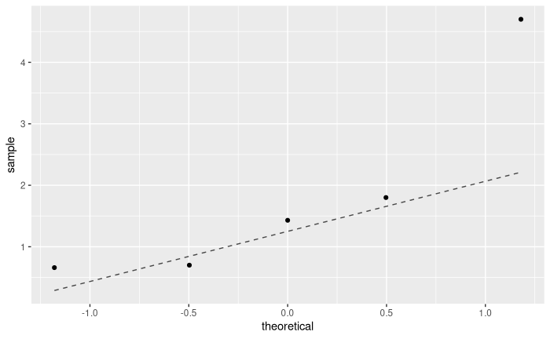

```r
X = c(1.8,4.7,.7,1.43,.66)
gf_qq(~X) %>% gf_qqline()
```

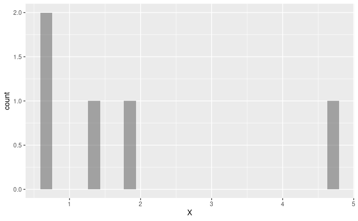

```r
gf_histogram(~X)
```

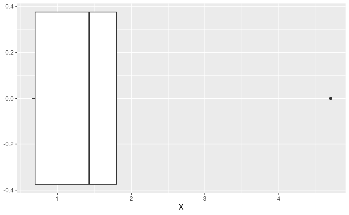

```r
gf_boxplot(~X)
```

```r
pnorm(.5,2,1) - pnorm(-1,2,1)
```

```
[1] 0.0654573
```

# Question 11

Use the R chunk below to load the data and perform any analysis needed.

```r
# run this code chunk to load the student data
mydata11 <- read.csv(file.choose())
t.test(MidtermScore ~ Section,conf.level = .95,data = mydata11)$conf.int
favstats(MidtermScore ~ Section,data = mydata11)
```

[output not shown]

# Questions 12-17

Use the code chunk below to perform any calculations for these questions that do not use data.

# Question 18

Use the code chunk below to read in the data and perform any needed calculations.

```r
# run this code chunk to load the student data
mydata18 <- read.csv(file.choose())
favstats(~BloodPressure,data = mydata18)
```

|  | min | Q1 | median | Q3 | max | mean | sd | n | missing |
| --- | --- | --- | --- | --- | --- | --- | --- | --- | --- |
|  | 76 | 108 | 120 | 146 | 220 | 128.5412 | 31.46788 | 85 | 0 |

```r
t.test(~BloodPressure,alternative = "greater",mu = 120, data = mydata18)
```

```
    One Sample t-test

data:  BloodPressure
t = 2.5024, df = 84, p-value = 0.007137
alternative hypothesis: true mean is greater than 120
95 percent confidence interval:
 122.8644      Inf
sample estimates:
mean of x
 128.5412
```

# Questions 19-20

Use the code chunk below to perform any calculations for these questions that do not use data.

```r
X = c(23, 36, 21, 18)
chisq.test(X)
```

```
    Chi-squared test for given probabilities

data:  X
X-squared = 7.7143, df = 3, p-value = 0.0523
```

# Question 21

Use the code chunk below to read in the data and perform any needed calculations.

```r
# run this code chunk to load the student data
mydata21 <- read.csv(file.choose())
mymodel <- lm(MPG~WT,data = mydata21)
summary(mymodel)
```

```
Call:
lm(formula = MPG ~ WT, data = mydata21)

Residuals:
    Min      1Q  Median      3Q     Max
-5.4595 -1.9004  0.1686  1.4032  6.4091

Coefficients:
            Estimate Std. Error t value Pr(>|t|)
(Intercept)   48.708      1.954   24.93  < 2e-16 ***
WT            -8.365      0.663  -12.62 8.89e-15 ***
---
Signif. codes:  0 ‘***’ 0.001 ‘**’ 0.01 ‘*’ 0.05 ‘.’ 0.1 ‘ ’ 1

Residual standard error: 2.851 on 36 degrees of freedom
Multiple R-squared:  0.8155,    Adjusted R-squared:  0.8104
F-statistic: 159.2 on 1 and 36 DF,  p-value: 8.889e-15
```

# Questions 22-23

Use the code chunk below to perform any calculations for these questions that do not use data.

# Question 24

Use the code chunk below to read in the data and perform any needed calculations.

```r
# run this code chunk to load the student data
mydata24 <- read.csv(file.choose())
favstats(Ozone ~ Month,data = mydata24)
```

| Month | min | Q1 | median | Q3 | max | mean | sd | n | missing |
| --- | --- | --- | --- | --- | --- | --- | --- | --- | --- |
| Feb | 325 | 350.0 | 365 | 395 | 560 | 377.2 | 55.91090 | 15 | 0 |
| Jan | 301 | 336.5 | 354 | 373 | 387 | 352.6 | 24.47681 | 15 | 0 |

# Remaining Questions

Use the code chunk below to perform any calculations for these questions that do not use data.